# Human Activity Recognition

Pablo Rodríguez

Friday, June 12, 2015

# Introduction

Here we’ll analyze a data set of various biometric variables.

Read more: http://groupware.les.inf.puc-rio.br/har#ixzz3d7cWJT3V

# Previous tasks

```r
# Set the seed
set.seed(28010)

# Load required libraries
library(caret)
library(randomForest)
library(dplyr)
```

# Data loading

```r
trainSet <- read.csv("pml-training.csv", row.names=1, na.strings = "")
testSet <- read.csv("pml-testing.csv", row.names=1, na.strings = "NA")
```

# Data cleaning

Remove problematic covariates:

```r
near0 <- nearZeroVar(trainSet, saveMetrics=TRUE)
trainSet <- trainSet[ , !near0$nzv]
testSet <- testSet[ , !near0$nzv]
```

Remove every column if contains at least one NA:

```r
trainSet <- trainSet[ , (colSums(is.na(trainSet)) == 0)]
testSet <- testSet[ , (colSums(is.na(testSet)) == 0)]
```

Remove unnecessary columns:

```r
trainSet <- select(trainSet, -user_name, -raw_timestamp_part_1, -raw_timestamp_part_2, -cvtd_timestamp, -num_window )
testSet <- select(testSet, -user_name, -raw_timestamp_part_1, -raw_timestamp_part_2, -cvtd_timestamp, -num_window, -problem_id )
```

Taking advantage of the large size of the train set, we’ll create a validation set:

```r
trainIndices <- createDataPartition(y=trainSet$classe, p=0.7, list=FALSE)
trainClean <- trainSet[trainIndices,]
valClean <- trainSet[-trainIndices,]
```

# Training

Perform the training; we’ll use the random forest method. I recommend to set cache = TRUE for this chunk, because it is a slow one:

```r
rfFit <- train(classe ~ ., method = "rf", data = trainClean, importance = T, trControl = trainControl(method = "cv", number = 4))
```

Use validation set for getting the confusion matrix:

```r
validation_pred <- predict(rfFit, newdata=valClean)
confusionMatrix(validation_pred,valClean$classe)
```

```
## Confusion Matrix and Statistics
##
##           Reference
## Prediction    A    B    C    D    E
##          A 1672    8    0    0    0
##          B    1 1129    3    0    2
##          C    0    2 1018    6    1
##          D    0    0    5  957    5
##          E    1    0    0    1 1074
##
## Overall Statistics
##
##                Accuracy : 0.9941
##                  95% CI : (0.9917, 0.9959)
##     No Information Rate : 0.2845
##     P-Value [Acc > NIR] : < 2.2e-16
##
##                   Kappa : 0.9925
##  Mcnemar's Test P-Value : NA
##
## Statistics by Class:
##
##                      Class: A Class: B Class: C Class: D Class: E
## Sensitivity            0.9988   0.9912   0.9922   0.9927   0.9926
## Specificity            0.9981   0.9987   0.9981   0.9980   0.9996
## Pos Pred Value         0.9952   0.9947   0.9912   0.9897   0.9981
## Neg Pred Value         0.9995   0.9979   0.9984   0.9986   0.9983
## Prevalence             0.2845   0.1935   0.1743   0.1638   0.1839
## Detection Rate         0.2841   0.1918   0.1730   0.1626   0.1825
## Detection Prevalence   0.2855   0.1929   0.1745   0.1643   0.1828
## Balanced Accuracy      0.9985   0.9950   0.9952   0.9954   0.9961
```

Overview the importance of each variable:

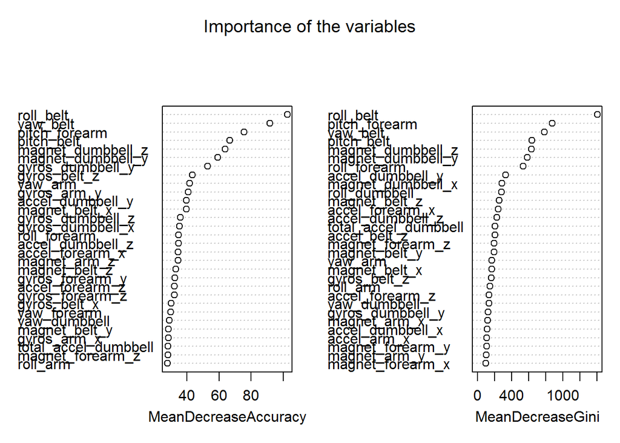

```r
imp <- varImp(rfFit)$importance
varImpPlot(rfFit$finalModel, sort = TRUE, main = "Importance of the variables")
```

# Predict

Use the model to predict for the testing set:

```r
testPred <- predict(rfFit, newdata=testSet)
```

So, the classification throws the following classes for the test observations:

```r
print(testPred)
```

```
##  [1] B A B A A E D B A A B C B A E E A B B B
## Levels: A B C D E
```

## Export results

We’ll use the function provided by Coursera:

```r
pml_write_files  <- function(x) {
    n <- length(x)
    for (i in 1:n) {
        filename <- paste0("problem_id", i, ".txt")
        write.table(x[i], file=filename, quote=FALSE, row.names=FALSE,col.names=FALSE)
    }
}

pml_write_files(testPred)
```